# tseLCA Workflow

```r
library(tseLCA)
```

## Overview

`tseLCA` implements the BCH and ML bias-adjusted three-step estimators for latent class analysis (LCA) with covariates and distal outcomes, following the methodological framework for both BCH and Vermunt’s ML approaches from Bakk, Tekle & Vermunt (2013). `tseLCA` also builds on top of the two-step LCA estimation procedure outlined by Bakk & Kuha (2018), and using the R package `multilevLCA` for efficient measurement model estimation from Lyrvall et al. (2025). `tseLCA` provides analytic sandwich variance estimation that propagates measurement uncertainty through the classification-error correction in the final step.

The three-step approach separates the model into:

1. **Step 1** — Estimate the LCA measurement model (class-conditional item probabilities and class prevalences).
2. **Step 2** — Assign posterior class probabilities and compute the misclassification matrix.
3. **Step 3** — Estimate the structural model (covariate effects or distal outcome means) using the bias-adjusted weights.

## Synthetic data

The built-in data-generating process replicates the design of Bakk & Kuha (2018). Each dataset has six binary indicators ($Y_1, \ldots, Y_6$) drawn from a three-class LCA, plus either a covariate $Z_p \sim \text{Uniform}\{1,\ldots,5\}$ predicting class membership, or a continuous distal outcome $Z_o$ predicted by class membership.

```r
# High separation: P(Y_h = 1 | class) = 0.9 / 0.1
d <- generate_data(
  n = 500,
  separation = "high",
  scenario = "covariate",
  seed = 1
)
head(d)
```

```
#>   Y1 Y2 Y3 Y4 Y5 Y6 X Zp
#> 1  1  1  1  0  0  0 2  1
#> 2  0  0  0  0  0  0 3  4
#> 3  1  0  1  0  0  0 2  1
#> 4  1  1  0  1  1  1 1  2
#> 5  0  0  0  0  0  0 3  5
#> 6  1  1  1  1  1  1 1  3
```

```r
# Low separation: P(Y_h = 1 | class) = 0.7 / 0.3
# Zp and X are identical to 'd' because seed = 1
d.low <- generate_data(
  n = 500,
  separation = "low",
  scenario = "covariate",
  seed = 1
)
head(d.low)
```

```
#>   Y1 Y2 Y3 Y4 Y5 Y6 X Zp
#> 1  1  1  1  0  0  0 2  1
#> 2  1  0  0  1  0  1 3  4
#> 3  0  0  1  0  0  0 2  1
#> 4  1  1  0  0  1  1 1  2
#> 5  0  0  1  1  1  0 3  5
#> 6  1  1  1  1  1  1 1  3
```

## Step 1: Measurement model

`three_step()` with no `Zp.names` or `Zo.name` fits the measurement model only, returning a `tseLCA_measurement` object. Internally this calls `multilevLCA::multiLCA()` with random restarts when entropy $R^2$ is low.

```r
d.measurement <- three_step(
  data = d,
  Y.names = paste0("Y", 1:6),
  n_classes = 3,
  measurement.tol = 1e-8
)
summary(d.measurement)
```

```
#> -- tseLCA Measurement Model --------------------------------
#> Latent classes : 3
#> Log-likelihood : -1455.5052
#> AIC            : 2951.0104
#> BIC            : 3035.3025
#> Entropy R²     : 0.8780
#>
#> Class prevalences:
#>
#> P(C1) 0.3570
#> P(C2) 0.3308
#> P(C3) 0.3122
#> attr(,"names")
#> [1] "C1" "C2" "C3"
#>
#> Item-response probabilities (P(Y=1|class)):
#>             C1     C2     C3
#> P(Y1|C) 0.9237 0.8621 0.1187
#> P(Y2|C) 0.9083 0.9219 0.1178
#> P(Y3|C) 0.9148 0.9571 0.0731
#> P(Y4|C) 0.8843 0.1481 0.0875
#> P(Y5|C) 0.8817 0.1340 0.1118
#> P(Y6|C) 0.9174 0.0889 0.1252
```

With low separation the measurement model can struggle to find the global maximum. Use `iter.measurement` to trigger the number of random restarts whenever entropy $R^2$ falls below `R2.threshold`.

```r
d.low.measurement <- three_step(
  data = d.low,
  Y.names = paste0("Y", 1:6),
  n_classes = 3,
  iter.measurement = 10,
  R2.threshold = 0.9
)
summary(d.low.measurement)
```

```
#> -- tseLCA Measurement Model --------------------------------
#> Latent classes : 3
#> Log-likelihood : -2019.2458
#> AIC            : 4078.4916
#> BIC            : 4162.7837
#> Entropy R²     : 0.3327
#>
#> Class prevalences:
#>
#> P(C1) 0.2753
#> P(C2) 0.4551
#> P(C3) 0.2696
#> attr(,"names")
#> [1] "C1" "C2" "C3"
#>
#> Item-response probabilities (P(Y=1|class)):
#>             C1     C2     C3
#> P(Y1|C) 0.7328 0.6418 0.3345
#> P(Y2|C) 0.5723 0.7549 0.3223
#> P(Y3|C) 0.6937 0.7101 0.3036
#> P(Y4|C) 0.6846 0.4588 0.2105
#> P(Y5|C) 0.6947 0.4058 0.3787
#> P(Y6|C) 0.8651 0.3551 0.2456
```

The `plot()` S3 method delegates to `multilevLCA`’s item-profile plot.

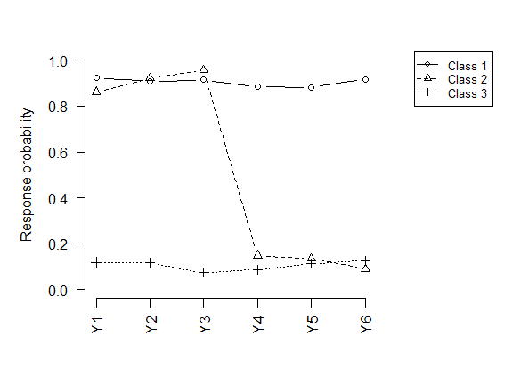

```r
plot(d.measurement)
```

## Two-step estimates

`fitZ_from_fit0()` fixes the measurement parameters at their Step-1 values and estimates multinomial logit coefficients $\gamma$ with EM. These two-step estimates serve as starting values for Step 3 and are generally close to the final three-step estimates.

```r
d.fitZ <- fitZ_from_fit0(
  fit0 = d.measurement$measurement_model$fit0,
  data = d,
  Y.names = paste0("Y", 1:6),
  Zp.names = "Zp"
)
# True slopes: -1 (C2) and +1 (C3) relative to C1
d.fitZ$mGamma
```

```
#>                   C2         C3
#> Intercept  2.1934130 -3.4524271
#> Zp        -0.9411383  0.8971774
```

Starting values from the high-separation fit can be passed to the low-separation fit to help it converge.

```r
d.low.fitZ <- fitZ_from_fit0(
  fit0 = d.low.measurement$measurement_model$fit0,
  data = d.low,
  Y.names = paste0("Y", 1:6),
  Zp.names = "Zp",
  starting_val = d.fitZ$mGamma
)
d.low.fitZ$mGamma
```

```
#>                   C2         C3
#> Intercept  3.0446359 -3.6948016
#> Zp        -0.9832601  0.9487392
```

## Three-Step estimation

### ML estimator (default)

A single `three_step()` call handles all three steps. By default it uses the ML correction of Vermunt (2010) and modal class assignment.

```r
d.three_step <- three_step(
  data = d,
  Y.names = paste0("Y", 1:6),
  n_classes = 3,
  Zp.names = "Zp"
)
summary(d.three_step)
```

```
#> -- tseLCA Three-step Covariate Model -----------------------
#> Latent classes : 3
#> Estimator      : ML
#> Log-likelihood : -1339.0650
#> AIC            : 2758.1299
#> BIC            : 2926.7143
#> Entropy R²     : 0.8693  (covariate-adjusted)
#>
#> Two-step (starting) estimates:
#>                C2      C3
#> Intercept  2.1934 -3.4524
#> Zp        -0.9411  0.8972
#>
#> Three-step estimates:
#>              Estimate Std.Error z.value     p.value
#> Intercept:C2   2.0411    0.3237  6.3050 < 0.001 ***
#> Zp:C2         -0.8821    0.1406 -6.2730 < 0.001 ***
#> Intercept:C3  -3.4836    0.5913 -5.8913 < 0.001 ***
#> Zp:C3          0.8985    0.1435  6.2606 < 0.001 ***
#> ---
#> Signif. codes: 0 '***' 0.001 '**' 0.01 '*' 0.05 '.' 0.1 ' ' 1
```

The standard `coef()` and `vcov()` S3 methods work on any `tseLCA` object.

```r
coef(d.three_step)
```

```
#>                   C2         C3
#> Intercept  2.0410764 -3.4835616
#> Zp        -0.8820801  0.8984978
```

```r
vcov(d.three_step)
```

```
#>              Intercept:C2        Zp:C2 Intercept:C3        Zp:C3
#> Intercept:C2  0.104798063 -0.041343485  -0.01048872  0.001510799
#> Zp:C2        -0.041343485  0.019772531   0.01121397 -0.001932282
#> Intercept:C3 -0.010488717  0.011213968   0.34964328 -0.082842095
#> Zp:C3         0.001510799 -0.001932282  -0.08284210  0.020597096
```

### Proportional assignment

With modal assignment (`use.modal.assignment = TRUE`, the default), the Jacobian in the measurement-uncertainty correction is not mathematically defined. Setting `use.modal.assignment = FALSE` uses soft posterior weights throughout, giving an analytic Jacobian and is recommended when separation is moderate or low. When `use.modal.assignment = TRUE`, the Jacobian $\frac{\partial\theta_2}{\partial\theta_1}$ computed using the full posterior weights (e.g., behaving as if `use.modal.assignment = FALSE`) to maintain well-defined derivatives, though three-step estimates would still be computed with modal assignment as specified. The different is negligible when separation is high.

```r
d.three_step.prop <- three_step(
  data = d,
  Y.names = paste0("Y", 1:6),
  n_classes = 3,
  Zp.names = "Zp",
  use.modal.assignment = FALSE
)
summary(d.three_step.prop)
```

```
#> -- tseLCA Three-step Covariate Model -----------------------
#> Latent classes : 3
#> Estimator      : ML
#> Log-likelihood : -1339.0617
#> AIC            : 2758.1234
#> BIC            : 2926.7078
#> Entropy R²     : 0.8680  (covariate-adjusted)
#>
#> Two-step (starting) estimates:
#>                C2      C3
#> Intercept  2.1934 -3.4524
#> Zp        -0.9411  0.8972
#>
#> Three-step estimates:
#>              Estimate Std.Error z.value     p.value
#> Intercept:C2   2.1096    0.3287  6.4183 < 0.001 ***
#> Zp:C2         -0.9121    0.1460 -6.2456 < 0.001 ***
#> Intercept:C3  -3.6508    0.6430 -5.6777 < 0.001 ***
#> Zp:C3          0.9367    0.1547  6.0563 < 0.001 ***
#> ---
#> Signif. codes: 0 '***' 0.001 '**' 0.01 '*' 0.05 '.' 0.1 ' ' 1
```

### Simple (robust) standard errors

Setting `use.simple.cov = TRUE` skips the measurement-uncertainty correction and returns the robust sandwich SEs from Step 3 only. When separation is high the correction is negligible, so this is a useful computational shortcut for large samples.

```r
d.three_step.simple <- three_step(
  data = d,
  Y.names = paste0("Y", 1:6),
  n_classes = 3,
  Zp.names = "Zp",
  use.simple.cov = TRUE
)
summary(d.three_step.simple)
```

```
#> -- tseLCA Three-step Covariate Model -----------------------
#> Latent classes : 3
#> Estimator      : ML
#> Log-likelihood : -1339.0650
#> AIC            : 2758.1299
#> BIC            : 2926.7143
#> Entropy R²     : 0.8693  (covariate-adjusted)
#>
#> Two-step (starting) estimates:
#>                C2      C3
#> Intercept  2.1934 -3.4524
#> Zp        -0.9411  0.8972
#>
#> Three-step estimates:
#>              Estimate Std.Error z.value     p.value
#> Intercept:C2   2.0411    0.3214  6.3504 < 0.001 ***
#> Zp:C2         -0.8821    0.1394 -6.3257 < 0.001 ***
#> Intercept:C3  -3.4836    0.5876 -5.9281 < 0.001 ***
#> Zp:C3          0.8985    0.1426  6.3008 < 0.001 ***
#> ---
#> Signif. codes: 0 '***' 0.001 '**' 0.01 '*' 0.05 '.' 0.1 ' ' 1
```

### BCH estimator

The BCH correction of Bolck, Croon & Hagenaars (2004) is available with `use.bch = TRUE`. It works well with high separation but can produce an ill-conditioned Hessian when separation is low (resulting in a covariance matrix that is not positive semi-definite), in which case the ML estimator is preferred.

```r
d.three_step.bch <- three_step(
  data = d,
  Y.names = paste0("Y", 1:6),
  n_classes = 3,
  Zp.names = "Zp",
  use.bch = TRUE
)
summary(d.three_step.bch)
```

```
#> -- tseLCA Three-step Covariate Model -----------------------
#> Latent classes : 3
#> Estimator      : BCH
#> Log-likelihood : -1339.1908
#> AIC            : 2758.3815
#> BIC            : 2926.9658
#> Entropy R²     : 0.8704  (covariate-adjusted)
#>
#> Two-step (starting) estimates:
#>                C2      C3
#> Intercept  2.1934 -3.4524
#> Zp        -0.9411  0.8972
#>
#> Three-step estimates:
#>              Estimate Std.Error z.value     p.value
#> Intercept:C2   2.0073    0.3157  6.3588 < 0.001 ***
#> Zp:C2         -0.8634    0.1330 -6.4912 < 0.001 ***
#> Intercept:C3  -3.3019    0.5410 -6.1032 < 0.001 ***
#> Zp:C3          0.8558    0.1326  6.4544 < 0.001 ***
#> ---
#> Signif. codes: 0 '***' 0.001 '**' 0.01 '*' 0.05 '.' 0.1 ' ' 1
```

BCH with low-separation data can fail to produce a positive semi-definite Hessian. The ML estimator with proportional assignment is more reliable in this setting.

```r
# Not run in vignette build (slow and and produces warnings)
bch.fail <- three_step(
  data = d.low,
  Y.names = paste0("Y", 1:6),
  n_classes = 3,
  Zp.names = "Zp",
  use.bch = TRUE,
  maxIter.measurement = 2000,
  iter.measurement = 10
)
```

```r
# Preferred approach for low separation
d.low.three_step.prop <- three_step(
  data = d.low,
  Y.names = paste0("Y", 1:6),
  n_classes = 3,
  Zp.names = "Zp",
  use.modal.assignment = FALSE
)
summary(d.low.three_step.prop)
```

```
#> -- tseLCA Three-step Covariate Model -----------------------
#> Latent classes : 3
#> Estimator      : ML
#> Log-likelihood : -1979.3372
#> AIC            : 4038.6744
#> BIC            : 4207.2588
#> Entropy R²     : 0.3518  (covariate-adjusted)
#>
#> Two-step (starting) estimates:
#>                C2      C3
#> Intercept  3.0267 -3.6919
#> Zp        -0.9767  0.9482
#>
#> Three-step estimates:
#>              Estimate Std.Error z.value     p.value
#> Intercept:C2   3.2034    2.2929  1.3971 0.1624
#> Zp:C2         -1.0761    1.9088 -0.5638 0.5729
#> Intercept:C3  -3.8431    2.9955 -1.2830 0.1995
#> Zp:C3          0.9554    0.6034  1.5832 0.1134
#> ---
#> Signif. codes: 0 '***' 0.001 '**' 0.01 '*' 0.05 '.' 0.1 ' ' 1
```

## Choosing the reference class

By default, class 1 (`"C1"`) is the reference category for the multinomial logit parameterization. The `rebase` argument changes this. Estimates are reparameterized consistently: log-likelihoods are invariant, and the coefficients satisfy the transitivity relation $\log(\pi_t / \pi_j) = \log(\pi_t / \pi_1) - \log(\pi_j / \pi_1)$.

```r
# Default: C1 as reference
summary(d.three_step.simple)
```

```
#> -- tseLCA Three-step Covariate Model -----------------------
#> Latent classes : 3
#> Estimator      : ML
#> Log-likelihood : -1339.0650
#> AIC            : 2758.1299
#> BIC            : 2926.7143
#> Entropy R²     : 0.8693  (covariate-adjusted)
#>
#> Two-step (starting) estimates:
#>                C2      C3
#> Intercept  2.1934 -3.4524
#> Zp        -0.9411  0.8972
#>
#> Three-step estimates:
#>              Estimate Std.Error z.value     p.value
#> Intercept:C2   2.0411    0.3214  6.3504 < 0.001 ***
#> Zp:C2         -0.8821    0.1394 -6.3257 < 0.001 ***
#> Intercept:C3  -3.4836    0.5876 -5.9281 < 0.001 ***
#> Zp:C3          0.8985    0.1426  6.3008 < 0.001 ***
#> ---
#> Signif. codes: 0 '***' 0.001 '**' 0.01 '*' 0.05 '.' 0.1 ' ' 1
```

```r
d.three_step.simpleC2 <- three_step(
  data = d,
  Y.names = paste0("Y", 1:6),
  n_classes = 3,
  Zp.names = "Zp",
  use.simple.cov = TRUE,
  rebase = "C2"
)
summary(d.three_step.simpleC2)
```

```
#> -- tseLCA Three-step Covariate Model -----------------------
#> Latent classes : 3
#> Estimator      : ML
#> Log-likelihood : -1339.0650
#> AIC            : 2758.1299
#> BIC            : 2926.7143
#> Entropy R²     : 0.8693  (covariate-adjusted)
#>
#> Two-step (starting) estimates:
#>                C1      C3
#> Intercept -2.1941 -5.6433
#> Zp         0.9413  1.8377
#>
#> Three-step estimates:
#>              Estimate Std.Error z.value     p.value
#> Intercept:C1  -2.0411    0.3214 -6.3504 < 0.001 ***
#> Zp:C1          0.8821    0.1394  6.3257 < 0.001 ***
#> Intercept:C3  -5.5246    0.6823 -8.0976 < 0.001 ***
#> Zp:C3          1.7806    0.2078  8.5696 < 0.001 ***
#> ---
#> Signif. codes: 0 '***' 0.001 '**' 0.01 '*' 0.05 '.' 0.1 ' ' 1
```

```r
d.three_step.simpleC3 <- three_step(
  data = d,
  Y.names = paste0("Y", 1:6),
  n_classes = 3,
  Zp.names = "Zp",
  use.simple.cov = TRUE,
  rebase = "C3"
)
summary(d.three_step.simpleC3)
```

```
#> -- tseLCA Three-step Covariate Model -----------------------
#> Latent classes : 3
#> Estimator      : ML
#> Log-likelihood : -1339.0650
#> AIC            : 2758.1299
#> BIC            : 2926.7143
#> Entropy R²     : 0.8693  (covariate-adjusted)
#>
#> Two-step (starting) estimates:
#>                C1      C2
#> Intercept  3.4492  5.6433
#> Zp        -0.8964 -1.8377
#>
#> Three-step estimates:
#>              Estimate Std.Error z.value     p.value
#> Intercept:C1   3.4836    0.5876  5.9281 < 0.001 ***
#> Zp:C1         -0.8985    0.1426 -6.3008 < 0.001 ***
#> Intercept:C2   5.5246    0.6823  8.0976 < 0.001 ***
#> Zp:C2         -1.7806    0.2078 -8.5696 < 0.001 ***
#> ---
#> Signif. codes: 0 '***' 0.001 '**' 0.01 '*' 0.05 '.' 0.1 ' ' 1
```

## Passing a pre-fitted measurement model

The `step1` argument accepts any previously fitted `tseLCA` object or the raw output of `lca_step1()`. This is useful when you want to:

- Reuse an expensive measurement model across multiple structural models.
- Estimate the measurement model on a large reference sample and apply it to a smaller analysis sample.
- Inject custom two-step starting values computed with `fitZ_from_fit0()`.

```r
# Reuse the measurement model estimated above
d.three_step.prop2 <- three_step(
  data = d,
  Y.names = paste0("Y", 1:6),
  n_classes = 3,
  Zp.names = "Zp",
  use.modal.assignment = FALSE,
  step1 = d.measurement$measurement_model
)
summary(d.three_step.prop2)
```

```
#> -- tseLCA Three-step Covariate Model -----------------------
#> Latent classes : 3
#> Estimator      : ML
#> Log-likelihood : -1339.0617
#> AIC            : 2758.1234
#> BIC            : 2926.7078
#> Entropy R²     : 0.8680  (covariate-adjusted)
#>
#> Two-step (starting) estimates:
#>                C2      C3
#> Intercept  2.1934 -3.4524
#> Zp        -0.9411  0.8972
#>
#> Three-step estimates:
#>              Estimate Std.Error z.value     p.value
#> Intercept:C2   2.1096    0.3287  6.4183 < 0.001 ***
#> Zp:C2         -0.9121    0.1460 -6.2456 < 0.001 ***
#> Intercept:C3  -3.6508    0.6430 -5.6777 < 0.001 ***
#> Zp:C3          0.9367    0.1547  6.0563 < 0.001 ***
#> ---
#> Signif. codes: 0 '***' 0.001 '**' 0.01 '*' 0.05 '.' 0.1 ' ' 1
```

```r
# Measurement model from a larger low-separation sample
d.low2000 <- generate_data(
  n = 2000,
  separation = "low",
  scenario = "covariate",
  seed = 2
)
d.low.measurement2000 <- three_step(
  data = d.low2000,
  Y.names = paste0("Y", 1:6),
  n_classes = 3
)

# Apply to the smaller sample; get.twostep.vcov returns multilevLCA's
# bias-corrected vcov for the two-step estimates
d.low.three_step.prop2 <- three_step(
  data = d.low,
  Y.names = paste0("Y", 1:6),
  n_classes = 3,
  Zp.names = "Zp",
  use.modal.assignment = FALSE,
  step1 = d.low.measurement2000$measurement_model,
  get.twostep.vcov = TRUE
)
summary(d.low.three_step.prop2)
```

```
#> -- tseLCA Three-step Covariate Model -----------------------
#> Latent classes : 3
#> Estimator      : ML
#> Log-likelihood : -1983.8234
#> AIC            : 4047.6468
#> BIC            : 4216.2311
#> Entropy R²     : 0.3770  (covariate-adjusted)
#>
#> Two-step (starting) estimates:
#>                C2      C3
#> Intercept  2.5851 -4.2908
#> Zp        -1.3556  1.0806
#>
#> Three-step estimates:
#>              Estimate Std.Error z.value     p.value
#> Intercept:C2   2.7051    1.1848  2.2831 0.0224  *
#> Zp:C2         -1.3769    0.9785 -1.4072 0.1594
#> Intercept:C3  -3.9488    2.0927 -1.8870 0.0592  .
#> Zp:C3          1.0303    0.4742  2.1730 0.0298  *
#> ---
#> Signif. codes: 0 '***' 0.001 '**' 0.01 '*' 0.05 '.' 0.1 ' ' 1
```

You can also compute two-step starting values separately and inject them before calling `three_step()`.

```r
d.low.fitZ2 <- fitZ_from_fit0(
  fit0 = d.low.measurement2000$measurement_model$fit0,
  data = d.low,
  Y.names = paste0("Y", 1:6),
  Zp.names = "Zp"
)
d.low.measurement2000$measurement_model$fitZ <- d.low.fitZ2

d.low.three_step.prop3 <- three_step(
  data = d.low,
  Y.names = paste0("Y", 1:6),
  n_classes = 3,
  Zp.names = "Zp",
  use.modal.assignment = FALSE,
  step1 = d.low.measurement2000$measurement_model
)
summary(d.low.three_step.prop3)
```

```
#> -- tseLCA Three-step Covariate Model -----------------------
#> Latent classes : 3
#> Estimator      : ML
#> Log-likelihood : -1983.8234
#> AIC            : 4047.6468
#> BIC            : 4216.2311
#> Entropy R²     : 0.3770  (covariate-adjusted)
#>
#> Two-step (starting) estimates:
#>                C2      C3
#> Intercept  2.5851 -4.2908
#> Zp        -1.3556  1.0806
#>
#> Three-step estimates:
#>              Estimate Std.Error z.value     p.value
#> Intercept:C2   2.7051    1.1848  2.2831 0.0224  *
#> Zp:C2         -1.3769    0.9785 -1.4072 0.1594
#> Intercept:C3  -3.9488    2.0927 -1.8870 0.0592  .
#> Zp:C3          1.0303    0.4742  2.1730 0.0298  *
#> ---
#> Signif. codes: 0 '***' 0.001 '**' 0.01 '*' 0.05 '.' 0.1 ' ' 1
```

## Fixed Step-1 initialization

`multilevLCA::multiLCA()`’s default initialization (k-means on principal components) is deterministic given the data, and on some datasets can converge to a local rather than global optimum of the Step-1 log-likelihood. The `startval` argument anchors Step 1 to a fixed starting classification instead, bypassing k-means entirely (`kmea = FALSE` under the hood).

`startval` accepts an integer classification vector (one predicted class per row)…

```r
startval.vec <- d.measurement$classifications
d.three_step.startval <- three_step(
  data = d,
  Y.names = paste0("Y", 1:6),
  n_classes = 3,
  Zp.names = "Zp",
  startval = startval.vec
)
summary(d.three_step.startval)
```

```
#> -- tseLCA Three-step Covariate Model -----------------------
#> Latent classes : 3
#> Estimator      : ML
#> Log-likelihood : -1339.0651
#> AIC            : 2758.1302
#> BIC            : 2926.7145
#> Entropy R²     : 0.8693  (covariate-adjusted)
#>
#> Two-step (starting) estimates:
#>                C2      C3
#> Intercept  2.1934 -3.4524
#> Zp        -0.9411  0.8972
#>
#> Three-step estimates:
#>              Estimate Std.Error z.value     p.value
#> Intercept:C2   2.0411    0.3237  6.3049 < 0.001 ***
#> Zp:C2         -0.8821    0.1406 -6.2730 < 0.001 ***
#> Intercept:C3  -3.4836    0.5913 -5.8913 < 0.001 ***
#> Zp:C3          0.8985    0.1435  6.2606 < 0.001 ***
#> ---
#> Signif. codes: 0 '***' 0.001 '**' 0.01 '*' 0.05 '.' 0.1 ' ' 1
```

…or a $T \times C$ conditional item-response probability matrix – e.g. from an external solver such as `poLCA`, or, as here, a first-pass tseLCA fit’s own `mPhi` expanded to both categories per item.

```r
phi.compact <- d.measurement$measurement_model$fit0$mPhi # 6 binary items x 3 classes
phi.full <- do.call(
  rbind,
  lapply(1:6, \(h) rbind(1 - phi.compact[h, ], phi.compact[h, ]))
)
d.three_step.startval.phi <- three_step(
  data = d,
  Y.names = paste0("Y", 1:6),
  n_classes = 3,
  Zp.names = "Zp",
  startval = phi.full
)
# Same solution as startval.vec above (both anchor Step 1 to the same fit)
summary(d.three_step.startval.phi)
```

```
#> -- tseLCA Three-step Covariate Model -----------------------
#> Latent classes : 3
#> Estimator      : ML
#> Log-likelihood : -1339.0650
#> AIC            : 2758.1299
#> BIC            : 2926.7142
#> Entropy R²     : 0.8693  (covariate-adjusted)
#>
#> Two-step (starting) estimates:
#>                C2      C3
#> Intercept  2.1934 -3.4524
#> Zp        -0.9411  0.8972
#>
#> Three-step estimates:
#>              Estimate Std.Error z.value     p.value
#> Intercept:C2   2.0411    0.3237  6.3050 < 0.001 ***
#> Zp:C2         -0.8821    0.1406 -6.2730 < 0.001 ***
#> Intercept:C3  -3.4836    0.5913 -5.8913 < 0.001 ***
#> Zp:C3          0.8985    0.1435  6.2606 < 0.001 ***
#> ---
#> Signif. codes: 0 '***' 0.001 '**' 0.01 '*' 0.05 '.' 0.1 ' ' 1
```

## Missing data

`tseLCA` uses a two-pass row-filtering strategy that matches `multilevLCA`’s approach for the measurement model while allowing more observations into Steps 1 and 2 than Step 3.

```r
set.seed(42)
d.new <- generate_data(500, separation = "high", seed = 3)
sparsity <- 0.1
missing <- 1 -
  matrix(
    rbinom(prod(dim(d.new)), size = 1, prob = sparsity),
    nrow = nrow(d.new),
    ncol = ncol(d.new)
  )
missing[missing == 0] <- NA_real_
d.sparse <- d.new * missing
head(d.sparse)
```

```
#>   Y1 Y2 Y3 Y4 Y5 Y6  X Zp
#> 1  0  0 NA  0  1  0  3  5
#> 2  1  1 NA  0  0  0  2  2
#> 3  1  1  1  1  1  0  1  4
#> 4  0  0  0  0  0  0  3  4
#> 5  1  1  1  0  0  0 NA  2
#> 6  1  1 NA  0  0  0  2  3
```

With `incomplete = FALSE` (the default), any row with a missing indicator is dropped before the measurement model is estimated.

```r
d.sparse.measurement <- three_step(
  data = d.sparse,
  Y.names = paste0("Y", 1:6),
  n_classes = 3,
  incomplete = FALSE,
  verbose = TRUE
)
```

```
#> 242 row(s) dropped from measurement/classification steps (missing Y).
```

```r
# Rows dropped = number of rows with at least one missing Y
sum(apply(d.sparse[, paste0("Y", 1:6)], 1, \(x) any(is.na(x))))
```

```
#> [1] 242
```

```r
summary(d.sparse.measurement)
```

```
#> -- tseLCA Measurement Model --------------------------------
#> Latent classes : 3
#> Log-likelihood : -742.0656
#> AIC            : 1524.1311
#> BIC            : 1595.1903
#> Entropy R²     : 0.9027
#>
#> Class prevalences:
#>
#> P(C1) 0.2995
#> P(C2) 0.3967
#> P(C3) 0.3037
#> attr(,"names")
#> [1] "C1" "C2" "C3"
#>
#> Item-response probabilities (P(Y=1|class)):
#>             C1     C2     C3
#> P(Y1|C) 0.8241 0.8869 0.0834
#> P(Y2|C) 0.8600 0.9104 0.0811
#> P(Y3|C) 0.9110 0.9344 0.0633
#> P(Y4|C) 0.9035 0.0486 0.1302
#> P(Y5|C) 0.9349 0.1517 0.0795
#> P(Y6|C) 0.9331 0.1555 0.0762
```

With `incomplete = TRUE`, only fully-missing rows are dropped; partially observed rows contribute to the measurement model through FIML.

```r
d.sparse.measurement2 <- three_step(
  data = d.sparse,
  Y.names = paste0("Y", 1:6),
  n_classes = 3,
  incomplete = TRUE,
  verbose = TRUE
)
summary(d.sparse.measurement2)
```

```
#> -- tseLCA Measurement Model --------------------------------
#> Latent classes : 3
#> Log-likelihood : -1342.8026
#> AIC            : 2725.6052
#> BIC            : 2809.8974
#> Entropy R²     : 0.8425
#>
#> Class prevalences:
#>
#> P(C1) 0.3049
#> P(C2) 0.3652
#> P(C3) 0.3299
#> attr(,"names")
#> [1] "C1" "C2" "C3"
#>
#> Item-response probabilities (P(Y=1|class)):
#>             C1     C2     C3
#> P(Y1|C) 0.8797 0.8916 0.0925
#> P(Y2|C) 0.8888 0.8858 0.0677
#> P(Y3|C) 0.9337 0.8859 0.1453
#> P(Y4|C) 0.9079 0.0819 0.1339
#> P(Y5|C) 0.9536 0.1359 0.1056
#> P(Y6|C) 0.9583 0.1590 0.1176
```

Regardless of `incomplete`, Step 3 drops any row with a missing covariate. The rows used in Step 3 are a subset of those used in Steps 1 and 2.

```r
d.sparse.three_step <- three_step(
  data = d.sparse,
  Y.names = paste0("Y", 1:6),
  n_classes = 3,
  Zp.names = "Zp",
  incomplete = TRUE,
  verbose = TRUE
)
```

```
#> 43 row(s) excluded from covariate step (missing Z).
#> fitZ EM converged in 9 iterations.
#> 43 row(s) excluded from covariate step (missing Z).
#> EM converged in 8 iterations.
```

```r
# Additional rows dropped from Step 3 due to missing Zp
sum(is.na(d.sparse$Zp))
```

```
#> [1] 43
```

```r
summary(d.sparse.three_step)
```

```
#> -- tseLCA Three-step Covariate Model -----------------------
#> Latent classes : 3
#> Estimator      : ML
#> Log-likelihood : -1088.3344
#> AIC            : 2256.6688
#> BIC            : 2421.6562
#> Entropy R²     : 0.8672  (covariate-adjusted)
#>
#> Two-step (starting) estimates:
#>                C2      C3
#> Intercept  2.5023 -4.6555
#> Zp        -1.0494  1.2929
#>
#> Three-step estimates:
#>              Estimate Std.Error z.value     p.value
#> Intercept:C2   2.4803    0.3807  6.5149 < 0.001 ***
#> Zp:C2         -1.0136    0.1667 -6.0789 < 0.001 ***
#> Intercept:C3  -4.7754    0.7267 -6.5716 < 0.001 ***
#> Zp:C3          1.3164    0.1796  7.3290 < 0.001 ***
#> ---
#> Signif. codes: 0 '***' 0.001 '**' 0.01 '*' 0.05 '.' 0.1 ' ' 1
```

A FIML measurement model can be passed in and then reused for the covariate step on the same sparse data.

```r
d.sparse.three_step2 <- three_step(
  data = d.sparse,
  Y.names = paste0("Y", 1:6),
  n_classes = 3,
  Zp.names = "Zp",
  incomplete = TRUE,
  step1 = d.sparse.measurement2$measurement_model,
  verbose = TRUE
)
```

```
#> 43 row(s) excluded from covariate step (missing Z).
#> fitZ EM converged in 9 iterations.
#> 43 row(s) excluded from covariate step (missing Z).
#> EM converged in 8 iterations.
```

```r
summary(d.sparse.three_step2)
```

```
#> -- tseLCA Three-step Covariate Model -----------------------
#> Latent classes : 3
#> Estimator      : ML
#> Log-likelihood : -1088.3344
#> AIC            : 2256.6688
#> BIC            : 2421.6562
#> Entropy R²     : 0.8672  (covariate-adjusted)
#>
#> Two-step (starting) estimates:
#>                C2      C3
#> Intercept  2.5023 -4.6555
#> Zp        -1.0494  1.2929
#>
#> Three-step estimates:
#>              Estimate Std.Error z.value     p.value
#> Intercept:C2   2.4803    0.3807  6.5149 < 0.001 ***
#> Zp:C2         -1.0136    0.1667 -6.0789 < 0.001 ***
#> Intercept:C3  -4.7754    0.7267 -6.5716 < 0.001 ***
#> Zp:C3          1.3164    0.1796  7.3290 < 0.001 ***
#> ---
#> Signif. codes: 0 '***' 0.001 '**' 0.01 '*' 0.05 '.' 0.1 ' ' 1
```